# Categorical Data in the Tidyverse

2020-08-20

# Introduction to Factor Variables

## Recognizing factor variables

There are two ways R can represent qualitative variables: as factors or as characters. In this exercise, you’ll try the two methods to find if `CurrentJobTitleSelect` is a factor. The dataset `multiple_choice_responses` has been loaded for you.

```r
library('readr')

multiple_choice_responses <- read_csv('DataScience_Survey_Data/multipleChoiceResponses.csv')

# Print out the dataset
head(multiple_choice_responses)
```

```
# A tibble: 6 x 228
  GenderSelect Country   Age EmploymentStatus StudentStatus LearningDataSci…
  <chr>        <chr>   <dbl> <chr>            <chr>         <chr>
1 Non-binary,… <NA>       NA Employed full-t… <NA>          <NA>
2 Female       United…    30 Not employed, b… <NA>          <NA>
3 Male         Canada     28 Not employed, b… <NA>          <NA>
4 Male         United…    56 Independent con… <NA>          <NA>
5 Male         Taiwan     38 Employed full-t… <NA>          <NA>
6 Male         Brazil     46 Employed full-t… <NA>          <NA>
# … with 222 more variables: CodeWriter <chr>, CareerSwitcher <chr>,
#   CurrentJobTitleSelect <chr>, TitleFit <chr>, CurrentEmployerType <chr>,
#   MLToolNextYearSelect <chr>, MLMethodNextYearSelect <chr>,
#   LanguageRecommendationSelect <chr>, PublicDatasetsSelect <chr>,
#   LearningPlatformSelect <chr>, LearningPlatformUsefulnessArxiv <chr>,
#   LearningPlatformUsefulnessBlogs <chr>,
#   LearningPlatformUsefulnessCollege <chr>,
#   LearningPlatformUsefulnessCompany <chr>,
#   LearningPlatformUsefulnessConferences <chr>,
#   LearningPlatformUsefulnessFriends <chr>,
#   LearningPlatformUsefulnessKaggle <chr>,
#   LearningPlatformUsefulnessNewsletters <chr>,
#   LearningPlatformUsefulnessCommunities <chr>,
#   LearningPlatformUsefulnessDocumentation <chr>,
#   LearningPlatformUsefulnessCourses <chr>,
#   LearningPlatformUsefulnessProjects <chr>,
#   LearningPlatformUsefulnessPodcasts <chr>,
#   LearningPlatformUsefulnessSO <chr>,
#   LearningPlatformUsefulnessTextbook <chr>,
#   LearningPlatformUsefulnessTradeBook <chr>,
#   LearningPlatformUsefulnessTutoring <chr>,
#   LearningPlatformUsefulnessYouTube <chr>,
#   BlogsPodcastsNewslettersSelect <chr>, LearningDataScienceTime <chr>,
#   JobSkillImportanceBigData <chr>, JobSkillImportanceDegree <chr>,
#   JobSkillImportanceStats <chr>, JobSkillImportanceEnterpriseTools <chr>,
#   JobSkillImportancePython <chr>, JobSkillImportanceR <chr>,
#   JobSkillImportanceSQL <chr>, JobSkillImportanceKaggleRanking <chr>,
#   JobSkillImportanceMOOC <chr>, JobSkillImportanceVisualizations <chr>,
#   JobSkillImportanceOtherSelect1 <chr>, JobSkillImportanceOtherSelect2 <chr>,
#   JobSkillImportanceOtherSelect3 <chr>, CoursePlatformSelect <chr>,
#   HardwarePersonalProjectsSelect <chr>, TimeSpentStudying <chr>,
```

[output cut: 12 more lines]

```
#   WorkAlgorithmsSelect <chr>, WorkToolsSelect <chr>,
#   WorkToolsFrequencyAmazonML <chr>, WorkToolsFrequencyAWS <chr>,
#   WorkToolsFrequencyAngoss <chr>, WorkToolsFrequencyC <chr>,
#   WorkToolsFrequencyCloudera <chr>, WorkToolsFrequencyDataRobot <chr>,
#   WorkToolsFrequencyFlume <chr>, WorkToolsFrequencyGCP <chr>,
#   WorkToolsFrequencyHadoop <chr>, WorkToolsFrequencyIBMCognos <chr>,
#   WorkToolsFrequencyIBMSPSSModeler <chr>,
#   WorkToolsFrequencyIBMSPSSStatistics <chr>,
#   WorkToolsFrequencyIBMWatson <chr>, WorkToolsFrequencyImpala <chr>,
#   WorkToolsFrequencyJava <chr>, WorkToolsFrequencyJulia <chr>,
#   WorkToolsFrequencyJupyter <chr>, WorkToolsFrequencyKNIMECommercial <lgl>,
#   WorkToolsFrequencyKNIMEFree <chr>, WorkToolsFrequencyMathematica <chr>,
#   WorkToolsFrequencyMATLAB <chr>, WorkToolsFrequencyAzure <chr>,
#   WorkToolsFrequencyExcel <chr>, WorkToolsFrequencyMicrosoftRServer <chr>,
#   WorkToolsFrequencyMicrosoftSQL <chr>, …
```

```r
# Check if CurrentJobTitleSelect is a factor
is.factor(multiple_choice_responses$CurrentJobTitleSelect)
```

```
[1] FALSE
```

## Understanding your qualitative variables

## Getting number of levels

`mutate()` and `summarise()` in dplyr both have variants where you can add the suffix `if` or all to change the operation. `mutate_if()` and `summarise_if` apply their second argument, a function, to all columns where the first argument is t`rue`, and `mutate_all()` and `summarise_all()` take one argument, a function, and apply it to all columns.

We’ll use these along with `tidyr` to get the number of levels for each factor variable in `multiple_choice_responses`. `gather()` from tidyr takes a dataset from wide to long format. Its two arguments are the new column names - one contain the old column names and one all the values.

```r
library("formatR")
library("dplyr")
library("tidyr")

# Change all the character columns to factors
responses_as_factors <- multiple_choice_responses %>% mutate_if(is.character, as.factor)

number_of_levels <- responses_as_factors %>% # apply the function nlevels to each column
summarise_all(nlevels) %>% # change the dataset from wide to long
gather(variable, num_levels)
```

There are more handy functions, `summarise_at()` and `mutate_at()`. These let you select columns by name-based select helpers.

## Examining number of levels

`dplyr` has two other functions that can come in handy when exploring a dataset. The first is `top_n(x, var)`, which gets us the first x rows of a dataset based on the value of var. The other is `pull()`, which allows us to extract a column and take out the name, leaving only the value(s) from the column.

```r
# Select the 3 rows with the highest number of levels
number_of_levels %>% top_n(3, num_levels)
```

```
# A tibble: 3 x 2
  variable               num_levels
  <chr>                       <int>
1 LearningPlatformSelect       5362
2 WorkToolsSelect              5248
3 WorkMethodsSelect            6190
```

```r
number_of_levels %>% # filter for where the column called variable equals CurrentJobTitleSelect
filter(variable == "CurrentJobTitleSelect") %>% # pull num_levels
pull(num_levels)
```

```
[1] 16
```

## Examining levels

Let’s continue to build our understanding of `CurrentJobTitleSelect`. In the previous exercise, we were able to get how many levels it has, but the other important part is what those levels are. Just like the last exercise, we’ll use `pull` to get the values of `CurrentJobTitleSelect` from the dataset `responses_as_factors`. `pull` can be used interchangeably with `$` as a way to extract a column as a vector from a table. For example, `mean(mtcars$mpg)` is the same as `mean(mtcars %>% pull(mpg))` or `mtcars %>% pull(mpg) %>% mean()`.

```r
responses_as_factors %>% # pull CurrentJobTitleSelect
pull(CurrentJobTitleSelect) %>% # get the values of the levels
levels()
```

```
 [1] "Business Analyst"
 [2] "Computer Scientist"
 [3] "Data Analyst"
 [4] "Data Miner"
 [5] "Data Scientist"
 [6] "DBA/Database Engineer"
 [7] "Engineer"
 [8] "Machine Learning Engineer"
 [9] "Operations Research Practitioner"
[10] "Other"
[11] "Predictive Modeler"
[12] "Programmer"
[13] "Researcher"
[14] "Scientist/Researcher"
[15] "Software Developer/Software Engineer"
[16] "Statistician"
```

## Reordering a variable by its frequency

Making effective visualizations is a big part of analyzing data. It’s not about having all the information on the plot; how you display the information can change whether or how quickly someone can understand the message. One of the primary purposes of the `forcats` package is to make it easy to quickly change your visualizations when you’re working with qualitative variables.

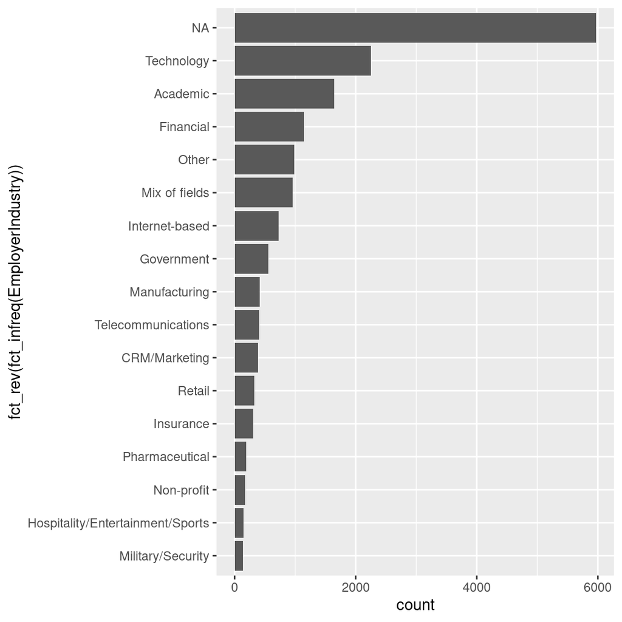

```r
library("forcats")
library("ggplot2")
# Make a bar plot
ggplot(multiple_choice_responses, aes(x = fct_rev(fct_infreq(EmployerIndustry)))) +
    geom_bar() + # flip the coordinates
coord_flip()
```

## Ordering one variable by another

Often we’ll need to modify our dataset before we can plot it. If we do this with `dplyr` functions and the pipe, `%>%`, you can continue by `%>%` your dataset into `ggplot()`. It works just like all the functions you use the `%>%` for because data is the first argument `ggplot()` takes, and then you can write the rest of the arguments (like `aes()`) inside the `ggplot()` call. Just don’t forget you have to switch back to `+` when you add on the rest of the `ggplot()` code!

Let’s try it out by first modifying `multiple_choice_responses` and then plotting the results in a scatterplot. We’ll also need a `forcats` function to put our graph in a better order.

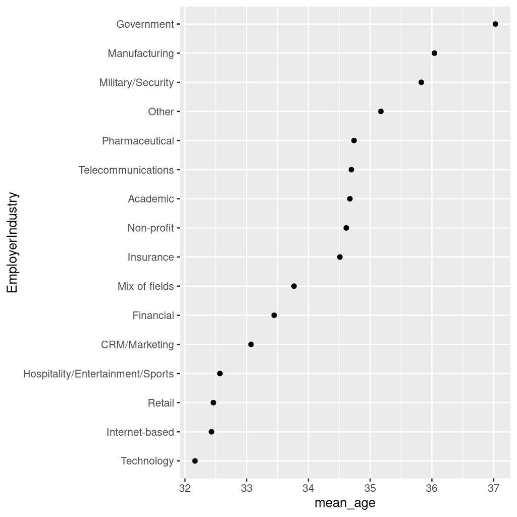

```r
multiple_choice_responses %>% # remove NAs
filter(!is.na(EmployerIndustry) & !is.na(Age)) %>% # get mean_age by EmployerIndustry
group_by(EmployerIndustry) %>% summarise(mean_age = mean(Age)) %>% # reorder EmployerIndustry by mean_age
mutate(EmployerIndustry = fct_reorder(EmployerIndustry, mean_age)) %>% # make a scatterplot of EmployerIndustry by mean_age
ggplot(aes(x = EmployerIndustry, y = mean_age)) + geom_point() + coord_flip()
```